# BIOEE 3550/6550 : **Data analysis and visualization in ecology and environmental science**

### *Spring 2025*

### Instructor: **Xiangtao Xu** ( ✉️ xx286@cornell.edu)

### Teaching Assistant: **Yixin Ma** (✉️ ym524@cornell.edu)

## Lab 4 *Correlation and Linear Regression*

In this Lab, the main learning objectives include: - Practice correlation analysis for linear and circular data - Generate polar coordinate plots - Practice OLS regressions and interpret the diagnostics - Generate diagnostic figures for OLS regressions

For R users, please install necessary packages by running the following commands in your console `install.packages(c('circular','Rfast','lmtest','GGally'),dep=TRUE)`

### 0. Codes used in lecture

We will use the flux tower data at Howland Forest in Maine `flux_ho1_halfhourly.csv` as a demonstration data set

#### 0.1 Correlation

```r
library(tidyverse)

df_flux <- read_csv('./flux_ho1_halfhourly.csv',show_col_types = FALSE)

print(head(df_flux))
```

```
## # A tibble: 6 × 50
##   TIMESTAMP_START TIMESTAMP_END   NEE     H    LE  FCH4     USTAR SW_IN SW_OUT
##             <dbl>         <dbl> <dbl> <dbl> <dbl> <dbl>     <dbl> <dbl>  <dbl>
## 1    201112312330  201201010000 -9999 -9999 -9999 -9999     0.185     0 -0.879
## 2    201201010000  201201010030 -9999 -9999 -9999 -9999     0.149     0 -0.068
## 3    201201010030  201201010100 -9999 -9999 -9999 -9999     0.117     0  0.253
## 4    201201010100  201201010130 -9999 -9999 -9999 -9999     0.462     0  0.56
## 5    201201010130  201201010200 -9999 -9999 -9999 -9999     0.417     0  0.109
## 6    201201010200  201201010230 -9999 -9999 -9999 -9999 -9999         0  0.324
## # ℹ 41 more variables: LW_IN <dbl>, LW_OUT <dbl>, NETRAD <dbl>, PPFD_IN <dbl>,
## #   VPD <dbl>, RH <dbl>, PA <dbl>, TA <dbl>, P <dbl>, TS_1 <dbl>, TS_2 <dbl>,
## #   WTD <dbl>, GPP_NT <dbl>, RECO_NT <dbl>, GPP_DT <dbl>, RECO_DT <dbl>,
## #   WD <dbl>, WS <dbl>, NEE_F <dbl>, H_F <dbl>, LE_F <dbl>, FCH4_F <dbl>,
## #   SW_IN_F <dbl>, SW_OUT_F <dbl>, LW_IN_F <dbl>, LW_OUT_F <dbl>,
## #   NETRAD_F <dbl>, PPFD_IN_F <dbl>, VPD_F <dbl>, RH_F <dbl>, PA_F <dbl>,
## #   TA_F <dbl>, P_F <dbl>, WTD_F <dbl>, WS_F <dbl>, LE_F_ANNOPTLM <dbl>, …
```

```r
library(lubridate) # this is the library that allows us to easily extract date information

# Convert the Time column to datetime type
dt_flux <- ymd_hm(df_flux$TIMESTAMP_START)
# you can also use as.POSIXct with format as an argument

# Extract year, month, and day of year
df_flux$DOY   <- yday(dt_flux)
df_flux$YEAR  <- year(dt_flux)
df_flux$MONTH <- month(dt_flux)
df_flux$HOD   <- hour(dt_flux) + minute(dt_flux) / 60 # hour of day
```

We will check the correlation between (1) latent energy `LE` - a measure of evapotranspiration, (2) incoming solar radiation `SW_IN_F`, and (3) air temperature at midday `TA_F` (midday defined as hour of day equal to 12)

```r
df_corr <- df_flux %>%
  filter(HOD == 12) %>%
  select(LE_F, SW_IN_F, TA_F) %>%
  mutate(across(everything(), ~ ifelse(. <= -9999, NA, .))) %>% # Replace invalid values with NA
  drop_na() # Remove rows with NA values

# Rename columns
colnames(df_corr) <- c("LE", "SW_IN", "TA")
```

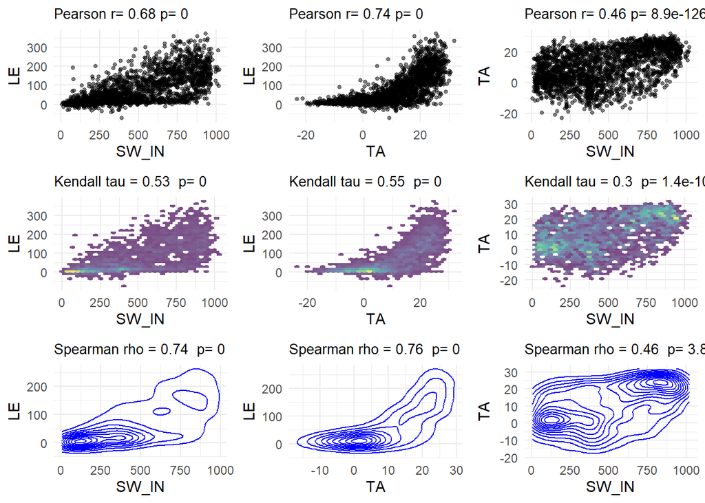

```r
library(ggplot2)
library(cowplot)
x_vars <- c("SW_IN", "TA", "SW_IN")
y_vars <- c("LE", "LE", "TA")

# List to store plots
scatter_plots <- list()
hexbin_plots <- list()
kde_plots <- list()

# Loop through variables and generate plots
for (i in seq_along(x_vars)) {

  # Scatter plot with Pearson correlation
  corr_coef = round(cor(df_corr[[x_vars[i]]], df_corr[[y_vars[i]]], method = "pearson"),2)
  p = cor.test(df_corr[[x_vars[i]]], df_corr[[y_vars[i]]], method = "pearson")$p.value
  p = signif(p,digits=2) # convert to scientific notation with two digits
  p1 <- ggplot(df_corr, aes_string(x = x_vars[i], y = y_vars[i])) +
    geom_point(alpha = 0.5, size = 1) +
    labs(x = x_vars[i], y = y_vars[i],
         title=paste("Pearson r=",corr_coef,"p=",p)) +
    theme_minimal()+
    theme(plot.title=element_text(size=10))


  scatter_plots[[i]] <- p1

  # Hexbin plot with Kendall correlation
  corr_coef = round(cor(df_corr[[x_vars[i]]], df_corr[[y_vars[i]]], method = "kendall"),2)
  p = cor.test(df_corr[[x_vars[i]]], df_corr[[y_vars[i]]], method = "kendall")$p.value
  p = signif(p,digits=2) # convert to scientific notation with two digits
  p2 <- ggplot(df_corr, aes_string(x = x_vars[i], y = y_vars[i])) +
    geom_hex(bins = 30, alpha = 0.7) +
    scale_fill_viridis_c() +
    labs(x = x_vars[i], y = y_vars[i],
         title = paste("Kendall tau =",corr_coef,' p=',p)) +
    theme_minimal() +
    theme(legend.position = 'none')+
    theme(plot.title=element_text(size=10))

  hexbin_plots[[i]] <- p2

  # KDE density plot with Spearman correlation
  corr_coef = round(cor(df_corr[[x_vars[i]]], df_corr[[y_vars[i]]], method = "spearman"),2)
  p = cor.test(df_corr[[x_vars[i]]], df_corr[[y_vars[i]]], method = "spearman")$p.value
  p = signif(p,digits=2) # convert to scientific notation with two digits
  p3 <- ggplot(df_corr, aes_string(x = x_vars[i], y = y_vars[i])) +
    geom_density_2d(color = "blue") +
    labs(x = x_vars[i], y = y_vars[i],
         title = paste("Spearman rho =",corr_coef,' p=',p)) +
    theme_minimal()+
    theme(plot.title=element_text(size=10))

  kde_plots[[i]] <- p3
}
# Combine all plots into a grid using cowplot
final_plot <- plot_grid(
  plot_grid(plotlist = scatter_plots, ncol = 3),
  plot_grid(plotlist = hexbin_plots, ncol = 3),
  plot_grid(plotlist = kde_plots, ncol = 3),
  nrow = 3
)

# Display final plot
print(final_plot)
```

#### 0.2 circular data

We will check the wind direction data at Howland Forest

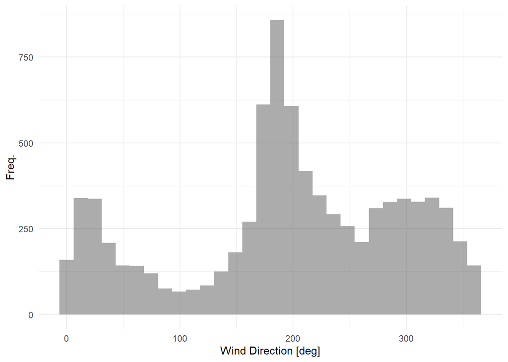

```r
June_wind_dir <- df_flux %>%
  filter(MONTH == 6, WD > -9999) %>%
  select(WD)
# use select instead of pull here
# pull will return a vector while
# select will return a dataframe

p <- ggplot(June_wind_dir, aes(x = WD)) +
  geom_histogram(bins=30,alpha = 0.5,position="identity") +
  labs(x = "Wind Direction [deg]", y = "Freq.") +
  theme_minimal() # increase base font size
print(p)
```

HG: the above just makes a regular histogram, which is linear. That’s not ideal, since the wind direction data are circular. The next chunk of code makes a circular plot of the same information.

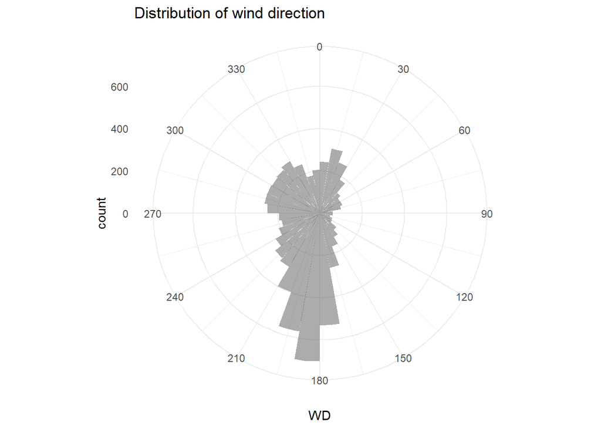

```r
# polar histogram

p <- ggplot(data=June_wind_dir) +
  geom_histogram(aes(x = WD), binwidth=10, boundary = 0, alpha = 0.5) +
  scale_x_continuous(limits = c(0, 360),
                     breaks = seq(0,330,30)) +
  coord_polar(start=0) + # plot the distribution in a polar coordinate system
  labs(title = "Distribution of wind direction") +
  theme_minimal()

print(p)
```

Now let’s prepare a data set that contains wind direction and net ecosystem exchange (NEE) in June, and we are interested in their diurnal variation.

```r
df_circ <- df_flux %>%
  filter(MONTH == 6) %>%                      # Filter for June
  select(DOY, HOD, NEE_F, WD) %>%             # Select relevant columns
  mutate(across(everything(), ~ ifelse(. < -100, NA, .))) %>% # Replace values < -100 with NA
  drop_na()                                   # Remove rows with NA values
colnames(df_circ) <- c('DOY','HOD','NEE','WD')
```

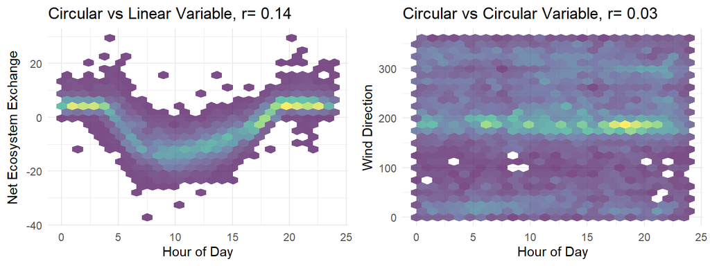

```r
# Hexbin plot with Kendall correlation
corr_coef = round(cor(df_circ$HOD,df_circ$NEE, method = "pearson"),2)
p1 <- ggplot(data=df_circ, aes(x = HOD, y = NEE)) +
  geom_hex(bins = 25, alpha = 0.7) +
  scale_fill_viridis_c()+
  labs(x='Hour of Day',
       y='Net Ecosystem Exchange',
       title = paste("Circular vs Linear Variable, r=",corr_coef)) +
  theme_minimal() +
  theme(legend.position = 'none')

corr_coef = round(cor(df_circ$HOD,df_circ$WD, method = "pearson"),2)
p2 <-ggplot(data=df_circ, aes(x = HOD, y = WD)) +
  geom_hex(bins = 25, alpha = 0.7) +
  scale_fill_viridis_c()+
  labs(x='Hour of Day',
       y='Wind Direction',
       title = paste("Circular vs Circular Variable, r=",corr_coef)) +
  theme_minimal() +
  theme(legend.position = 'none')

p <- plot_grid(p1,p2,ncol=2)
print(p)
```

HG: I do not understand what the difference is between the above chunk and the below chunk. This is where he said that this is two different ways to get the same output, but the *r* is different between the two outputs???

```r
# use circular statistics
library(circular) # for cor.circular
library(Rfast) # for circlin.cor
```

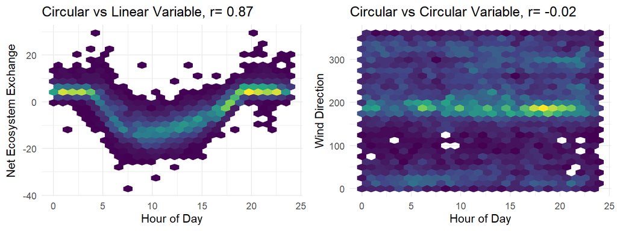

```r
phi_HOD = circular(df_circ$HOD / 24 * 2 * pi)
phi_WD = circular(df_circ$WD / 360 * 2 * pi)
# convert to radian

# Circular to linear
corr_coef = round(
  sqrt(circlin.cor(phi_HOD,df_circ$NEE)),2)
# Correlation coefficient between one circular and one linear variable
# note that circlin.cor returns R2 instead of correlation coefficient R
# that's why we need the sqrt() operation
p1 <- ggplot(data=df_circ, aes(x = HOD, y = NEE)) +
  geom_hex(bins = 25) +
  scale_fill_viridis_c()+
  labs(x='Hour of Day',
       y='Net Ecosystem Exchange',
       title = paste("Circular vs Linear Variable, r=",corr_coef)) +
  theme_minimal() +
  theme(legend.position = 'none')

corr_coef = round(cor.circular(phi_HOD,phi_WD),2)
# Correlation coefficient between two circular variables.
p2 <-ggplot(data=df_circ, aes(x = HOD, y = WD)) +
  geom_hex(bins = 25) +
  scale_fill_viridis_c()+
  labs(x='Hour of Day',
       y='Wind Direction',
       title = paste("Circular vs Circular Variable, r=",corr_coef)) +
  theme_minimal() +
  theme(legend.position = 'none')

p <- plot_grid(p1,p2,ncol=2)
print(p)
```

#### 0.3 Regression

Regression can be used to characterize the sensitivity between X and Y, which is different for variable pairs with similar correlation.

```r
# here we are interested in the relationship between NEE and radiation in the morning VS afternoon
df_nee <- df_flux %>%
  select(NEE, SW_IN, MONTH, HOD) %>%
  mutate(across(everything(), ~ ifelse(. < -100, NA, .))) %>%
  drop_na()

# Subset morning data (HOD < 12) for July, then afternoon for the same
df_am <- df_nee %>%
  filter(MONTH == 7 & HOD < 12)

df_pm <- df_nee %>%
  filter(MONTH == 7 & HOD >= 12)
```

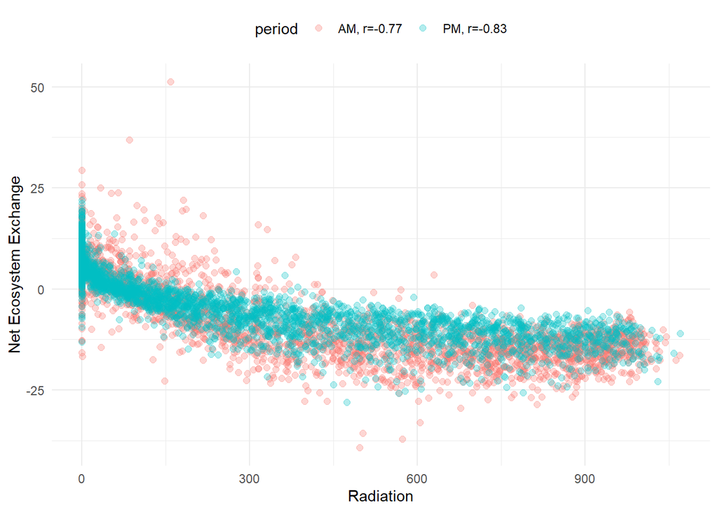

```r
# Compute Pearson correlation for morning and afternoon datasets
cor_am <- round(cor(df_am$SW_IN, df_am$NEE, method = "pearson"),2)
cor_pm <- round(cor(df_pm$SW_IN, df_pm$NEE, method = "pearson"),2)

# Create a combined dataset with time of day labels
# HG: this is so that you can get the labels to appear in the legend of the next plot
df_am <- df_am %>% mutate(period = paste0("AM, r=",cor_am))
df_pm <- df_pm %>% mutate(period = paste0("PM, r=",cor_pm))
df_combined <- bind_rows(df_am, df_pm)

# Scatter plot with different colors for AM and PM
ggplot(df_combined, aes(x = SW_IN, y = NEE, color = period)) +
  geom_point(size=2,alpha=0.3) +
  labs(x = "Radiation", y = "Net Ecosystem Exchange") +
  theme_minimal() +
  theme(legend.position = "top")
```

Let’s conduct a linear regression to check the sensitivity of NEE to Radiation using the PM data

```r
# regression for radiation
mod_1 = lm(NEE ~ SW_IN,data=df_pm)
summary(mod_1)
```

```
##
## Call:
## lm(formula = NEE ~ SW_IN, data = df_pm)
##
## Residuals:
##      Min       1Q   Median       3Q      Max
## -20.9579  -2.7922   0.0936   2.8535  18.5082
##
## Coefficients:
##               Estimate Std. Error t value Pr(>|t|)
## (Intercept)  3.4128074  0.1129407   30.22   <2e-16 ***
## SW_IN       -0.0220403  0.0002639  -83.52   <2e-16 ***
## ---
## Signif. codes:  0 '***' 0.001 '**' 0.01 '*' 0.05 '.' 0.1 ' ' 1
##
## Residual standard error: 4.595 on 3181 degrees of freedom
## Multiple R-squared:  0.6868, Adjusted R-squared:  0.6867
## F-statistic:  6976 on 1 and 3181 DF,  p-value: < 2.2e-16
```

```r
# how to interpret the results?
```

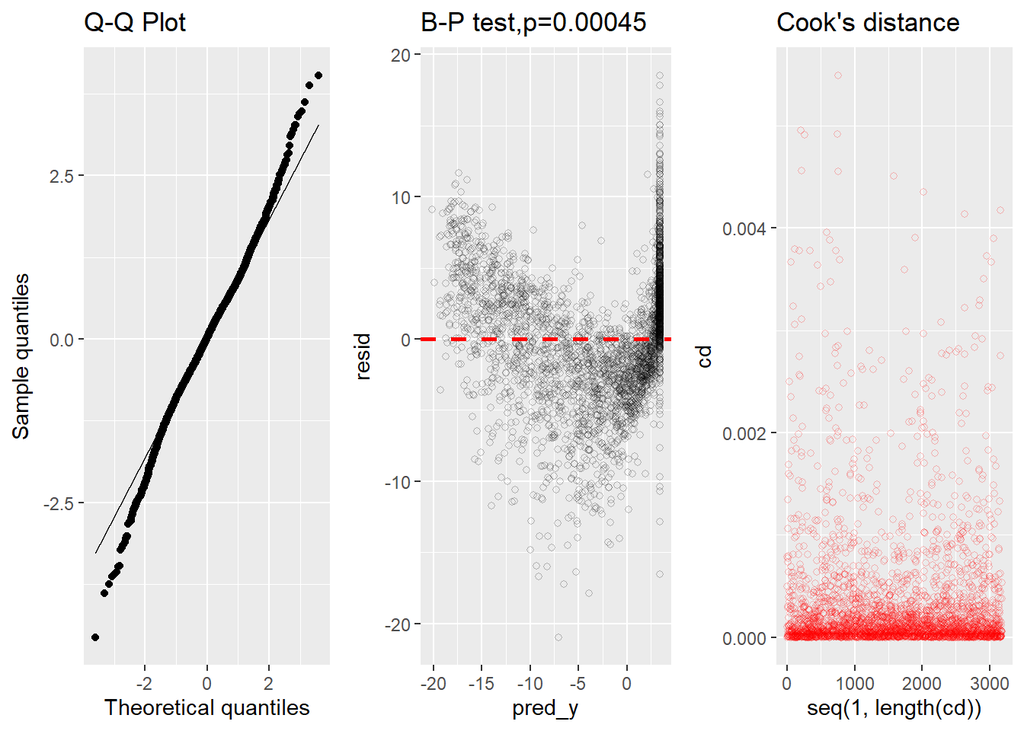

```r
# plot figures for diagnostics - normality, homoscedasticity, outliers
library(lmtest) # for bptest
# prepare data
plot_data = data.frame(pred_y = fitted(mod_1), resid = resid(mod_1), cd = cooks.distance(mod_1))

p1 <- ggplot(data=NULL,aes(sample = scale(plot_data$resid)), distribution = qnorm) +
  stat_qq() + stat_qq_line() +
  labs(x="Theoretical quantiles",
       y="Sample quantiles",
       title = "Q-Q Plot")

p_bp = bptest(mod_1)$p.value
p2 <- ggplot(data = plot_data,aes(x = pred_y, y = resid)) +
      geom_point(shape = 1, color = "black", alpha = 0.25) +
      geom_hline(yintercept = 0, linetype = "dashed", color = "red", size = 1) +
      labs(title = paste0("B-P test,p=",  p = signif(p_bp,digits=2)))
p3 <- ggplot(data = plot_data, aes(x=seq(1,length(cd)),y = cd)) +
      geom_point(shape = 1, color = "red",alpha = 0.25) +
      labs(title = "Cook's distance")

p <- plot_grid(p1,p2,p3,ncol=3)

print(p)
```

Prediction confidence intervals

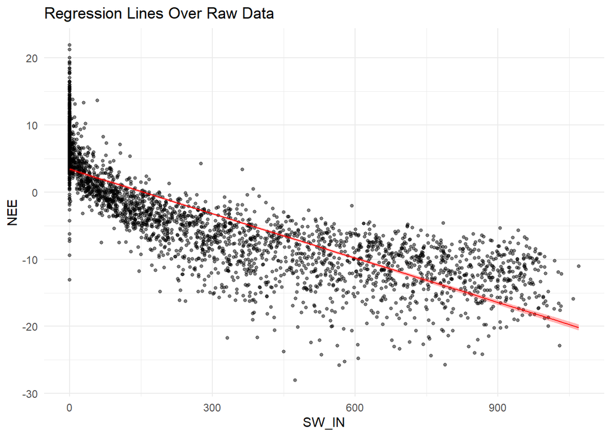

```r
# Predictions
newdata <- data.frame(SW_IN = seq(min(df_pm$SW_IN),
                                  max(df_pm$SW_IN),
                                  length.out = 20))
pred_nee <- predict(mod_1, newdata = newdata, interval = "confidence")
# confidence of the mean

df_pred = data.frame(SW_IN = newdata,
                     NEE = pred_nee[,1],
                     ci_lower = pred_nee[,2],
                     ci_upper = pred_nee[,3])
# Plot
ggplot() +
  geom_point(data = df_pm, aes(x = SW_IN, y = NEE), color = "black",
             size = 1, alpha = 0.5) +
  geom_line(data = df_pred, aes(x = SW_IN, y = NEE), color = "red") +
  geom_ribbon(data = df_pred, aes(x = SW_IN, ymin = ci_lower, ymax = ci_upper),
              fill = "red", alpha = 0.3) +
  labs(x = "SW_IN", y = "NEE", title = "Regression Lines Over Raw Data") +
  theme_minimal()
```

#### 0.4 Multiple Linear Regression

Prepare data

```r
# extract daytime NEE and associated environmental variables
# radiation, temperature, vapor pressure deficit, wind speed
df_mlr <- df_flux %>%
  filter(MONTH == 7 & HOD > 6 & HOD < 18) %>%
  select(NEE_F, SW_IN_F, TA_F, VPD_F, WS_F, HOD) %>%
  mutate(across(everything(), ~ ifelse(. < -100, NA, .))) %>%
  drop_na()
colnames(df_mlr) <- c('NEE','SW_IN','TA','VPD','WS','HOD')
```

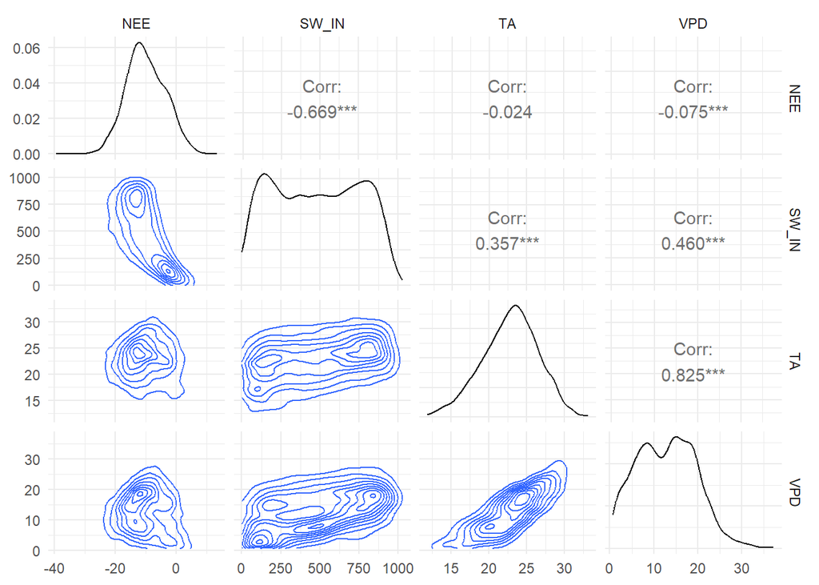

```r
library(GGally) # pairwise grid plots in ggplot style
# Create a pairwise histogram plot
ggpairs(df_mlr[, c("NEE", "SW_IN", "TA", "VPD")],
        lower = list(continuous = "density")) +  # Correlation in upper panel
  theme_minimal()
```

Set up model

```r
mod_mlr = lm(NEE ~ SW_IN + TA + VPD + WS + SW_IN : VPD,data=df_mlr)
# alternatively we can use
# mod_mlr = lm(NEE ~ SW_IN * VPD + TA + VPD + WS ,data=df_mlr)
summary(mod_mlr)
```

```
##
## Call:
## lm(formula = NEE ~ SW_IN + TA + VPD + WS + SW_IN:VPD, data = df_mlr)
##
## Residuals:
##      Min       1Q   Median       3Q      Max
## -25.1947  -2.2650   0.3394   2.6216  19.0313
##
## Coefficients:
##               Estimate Std. Error t value Pr(>|t|)
## (Intercept) -4.677e+00  5.577e-01  -8.386  < 2e-16 ***
## SW_IN       -3.043e-02  5.517e-04 -55.148  < 2e-16 ***
## TA           1.417e-01  3.029e-02   4.676 3.01e-06 ***
## VPD         -1.881e-01  2.498e-02  -7.529 6.20e-14 ***
## WS           1.033e+00  5.806e-02  17.784  < 2e-16 ***
## SW_IN:VPD    8.454e-04  3.751e-05  22.537  < 2e-16 ***
## ---
## Signif. codes:  0 '***' 0.001 '**' 0.01 '*' 0.05 '.' 0.1 ' ' 1
##
## Residual standard error: 4.082 on 4272 degrees of freedom
## Multiple R-squared:  0.5982, Adjusted R-squared:  0.5977
## F-statistic:  1272 on 5 and 4272 DF,  p-value: < 2.2e-16
```

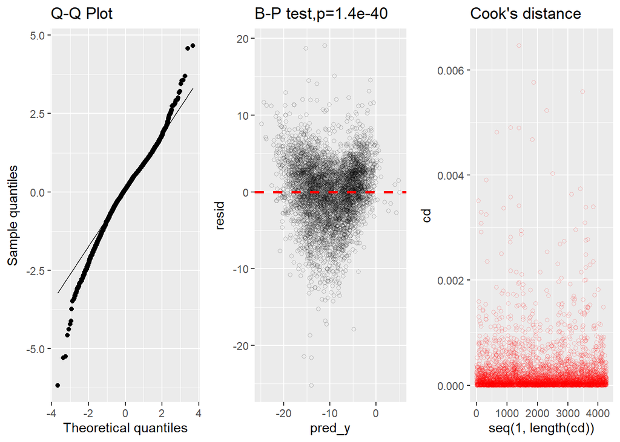

```r
# diagnostics

# prepare data
plot_data = data.frame(pred_y = fitted(mod_mlr),
                       resid = resid(mod_mlr),
                       cd = cooks.distance(mod_mlr))

p1 <- ggplot(data=NULL,aes(sample = scale(plot_data$resid)), distribution = qnorm) +
  stat_qq() + stat_qq_line() +
  labs(x="Theoretical quantiles",
       y="Sample quantiles",
       title = "Q-Q Plot")

p_bp = bptest(mod_mlr)$p.value
p2 <- ggplot(data = plot_data,aes(x = pred_y, y = resid)) +
      geom_point(shape = 1, color = "black", alpha = 0.25) +
      geom_hline(yintercept = 0, linetype = "dashed", color = "red", size = 1) +
      labs(title = paste0("B-P test,p=",  p = signif(p_bp,digits=2)))

p3 <- ggplot(data = plot_data, aes(x=seq(1,length(cd)),y = cd)) +
      geom_point(shape = 1, color = "red",alpha = 0.25) +
      labs(title = "Cook's distance")

p <- plot_grid(p1,p2,p3,ncol=3)

print(p)
```

Collinearity and VIF

```r
library(car)

# let's check the model without interactive effects
# it can be tricky to define and calculate VIF for models with interactive effect
VIF <- vif(mod_mlr)
print(VIF)
```

```
##     SW_IN        TA       VPD        WS SW_IN:VPD
##  5.816946  3.176078  7.144269  1.077632 12.243658
```

SW_IN:VPD has too strong collinearity, let’s remove it

```r
mod_mlr = lm(NEE ~ SW_IN + TA + VPD + WS ,data=df_mlr)
summary(mod_mlr)
```

```
##
## Call:
## lm(formula = NEE ~ SW_IN + TA + VPD + WS, data = df_mlr)
##
## Residuals:
##      Min       1Q   Median       3Q      Max
## -26.1760  -2.4737   0.3365   2.7799  18.9646
##
## Coefficients:
##               Estimate Std. Error t value Pr(>|t|)
## (Intercept) -7.8535553  0.5707070 -13.761   <2e-16 ***
## SW_IN       -0.0194517  0.0002743 -70.905   <2e-16 ***
## TA           0.0774488  0.0318963   2.428   0.0152 *
## VPD          0.2143708  0.0184743  11.604   <2e-16 ***
## WS           1.0838675  0.0613618  17.664   <2e-16 ***
## ---
## Signif. codes:  0 '***' 0.001 '**' 0.01 '*' 0.05 '.' 0.1 ' ' 1
##
## Residual standard error: 4.317 on 4273 degrees of freedom
## Multiple R-squared:  0.5504, Adjusted R-squared:   0.55
## F-statistic:  1308 on 4 and 4273 DF,  p-value: < 2.2e-16
```

```r
VIF <- vif(mod_mlr)
print(VIF)
```

```
##    SW_IN       TA      VPD       WS
## 1.285682 3.147985 3.493381 1.075974
```

#### Practice 1

Finish the following tasks based on the template above (and online search if needed):  
- We will work with the methane flux measurements `FCH4_F` and air temperature `TA_F` in the flux data we have been using.  
- Extract valid data in 2017, calculate average `FCH4_F` and `TA_F` for each day. The final dataset should contain three columns: `DOY`, `FCH4_F`, `TA_F`  
- Visualize seasonal cycle of daily `FCH4_F` and `TA_F` (`DOY` on the x axis, daily methane flux/temperature on the y axis)  
- Calculate the correlation coefficient for 1) `FCH4_F` and `DOY` 2) `TA_F` and `DOY` (hint: is DOY a circular variable?)  
- Based on the correlation coefficients, which one has a stronger seasonality, methane flux or temperature?  
- Does daily methane flux correlate with daily air temperature?

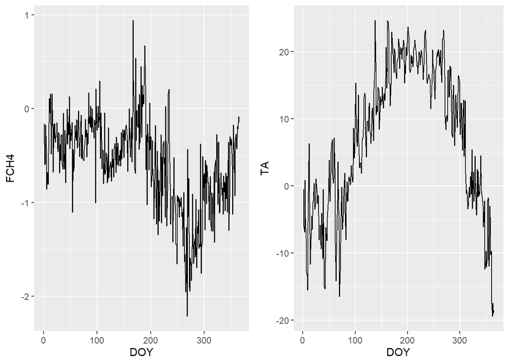

```r
df_pra1 <- df_flux |>
  filter(YEAR == 2017) |>
  select(DOY, FCH4_F, TA_F) |>
  mutate(across(everything(), ~ ifelse(. <= -9999, NA, .))) |>
  drop_na() |>
  group_by(DOY) |>
  summarise(FCH4 = mean(FCH4_F), TA = mean(TA_F))

p1 <- df_pra1 |>
  ggplot(aes(x = DOY, y = FCH4)) +
  geom_line()
p2 <- df_pra1 |>
  ggplot(aes(x = DOY, y = TA)) +
  geom_line()

p <- plot_grid(p1,p2,ncol=2)
print(p)
```

```r
## Calculate the correlation coefficient for 1) FCH4_F and DOY 2) TA_F and DOY (hint: is DOY a circular variable?)

# turn DOY into radians???
phi_DOY = circular(df_pra1$DOY / 365 * 2 * pi)

# for FCH4
corr_coef = round(
  sqrt(
    circlin.cor(
      phi_DOY,
      df_pra1$FCH4)),
  2)
print(corr_coef)
```

```
##      R-squared p-value
## [1,]      0.62       0
```

```r
# for TA
corr_coef <- round(
  sqrt(
    circlin.cor(
      phi_DOY,
      df_pra1$TA)),
  2)
print(corr_coef)
```

```
##      R-squared p-value
## [1,]      0.91       0
```

```r
## Based on the correlation coefficients, which one has a stronger seasonality, methane flux or temperature?

print("Temperature has a higher r-squared value, so has stronger seasonality(?)")
```

```
## [1] "Temperature has a higher r-squared value, so has stronger seasonality(?)"
```

```r
## Does daily methane flux correlate with daily air temperature?
```

#### Practice 2

Finish the following tasks based on the template above (and online search if needed):  
- Prepare a dataframe recording **daily** values of `FCH4_F`, `TA_F` (air temperature), `WTD_F` (water table depth), `SW_IN_F` (solar radiation), `P_F` (precipitation), and `WS_F` (wind speed). Please use valid data from 2013 to 2017 (5 years)  
- Use multiple linear regression to investigate what factors drive day-to-day variability in methane flux. Check diagnostics for this regression analysis.  
- Add the interactive effect of `P_F` and `TA_F` to the regression model. Based on the updated regression results, do these two variables have an interactive effect?

```r
## i spent all my time on practice 1 and have nothing for practice 2
```